# Εισαγωγή στην R και την Python

## 1.5 **Παραμετροποιήση των μοντέλων**

Πλέον μπορούμε να παραμετροποιήσουμε τα μοντέλα που θέλουμε να τρέξουμε:

```r
modelling_options <- BIOMOD_ModelingOptions()
```

Τώρα, προσδιορίζουμε ποιά μοντέλα θα τρέξουμε, καθώς και πολλές άλλες λεπτομέρειες:

```r
## Always change the name of this object, so as to match the name of your species
Yucca_brevifolia_models <- BIOMOD_Modeling( data = sp_formated_data,


                                       ## Here, we indicate which models we are
                                       ## going to run (remember that they need
                                       ## to be from the same group P/A ή P/O).
                                       ## Here, we are going to use some models
                                       ## belonging to the P/A group
                                       ## ('GLM','GBM','GAM','CTA','ANN','SRE',
                                       ## 'FDA','MARS','RF')
                                       models  =  c('RF', 'CTA'),

                                       models.options = modelling_options,

                                       ## How many times we will run the
                                       ## analysis in order to evaluate its'
                                       ## results [min: 10 - usually: 100]
                                       NbRunEval = 1,

                                       ## Training-Testing data split
                                       DataSplit = 80,

                                       ## How many times we will run the
                                       ## analysis in order to evaluate the
                                       ## importance of each IV [min: 10]
                                       VarImport = 1,

                                       ## Evaluation criteria
                                       models.eval.meth  =  c('TSS','ROC','KAPPA'),

                                       ## Whether or not we will save the results
                                       SaveObj  =  TRUE,

                                       ## Should the models be re-scaled in 0-1000 range?
                                       rescal.all.models  =  TRUE,

                                       ## Should our models be weighted based on all the data?
                                       do.full.models  =  TRUE,

                                       ## The name of our analysis
                                       modeling.id  =  "allmodels")
```

Ας φτιάξουμε τους φακέλους όπου θα αποθηκεύσουμε τα μοντέλα μας:

```r
## Create some folders to store our results
dir.create("./BIOMOD2 Modelling Outpout/", recursive = TRUE, showWarnings = FALSE)

dir.create("./BIOMOD2 Modelling Outpout/Species/", recursive = TRUE, showWarnings = FALSE)

dir.create("./BIOMOD2 Modelling Outpout/Species/Yucca_brevifolia", recursive = TRUE,
    showWarnings = FALSE)

dir.create("./BIOMOD2 Modelling Outpout/Species/Yucca_brevifolia/Current", recursive = TRUE,
    showWarnings = FALSE)


## Save the results in rds format
saveRDS(Yucca_brevifolia_models, "./BIOMOD2 Modelling Outpout/Species/Yucca_brevifolia/Current/Yucca_brevifolia models.rds")
```

## 1.6 **Αξιολόγηση των αρχικών μοντέλων**

Ας δημιουργήσουμε ένα αντικείμενο το οποίο θα περιέχει την αξιολόγηση των μοντέλων:

```r
Yucca_brevifolia_models_scores <- get_evaluations(Yucca_brevifolia_models)
```

## 1.7 **Σημαντικότητα μεταβλητών**

Ας δούμε τη σημαντικότητα των μεταβλητών για κάθε μοντέλο (`RF`, `CTA`), κάθε σετ δεδομένων (`PA1-2`) και κάθε επανάληψη (`Run`, `Full`):

```r
(Yucca_brevifolia_models_var_import <- get_variables_importance(Yucca_brevifolia_models))
```

Ας δούμε τη σημαντικότητα των μεταβλητών για κάθε μοντέλο (`RF`, `CTA`) συνολικά (δηλαδή τον μέσο όρο):

```r
options(digits = 2)
apply(Yucca_brevifolia_models_var_import, c(1, 2), mean)
```

```
##                 RF  CTA
## bio_2        0.108 0.27
## bio_4        0.117 0.16
## bio_8        0.122 0.26
## bio_9        0.082 0.25
## bio_13       0.045 0.11
## bio_18       0.097 0.23
## USA1_msk_alt 0.156 0.32
```

## 1.8 **Ensemble modelling**

Τώρα θα τρέξουμε την ανάλυση που θα ενώνει τα αποτελέσματα των δύο μοντέλων (ονομάζεται ensemble modelling αυτή η τεχνική ανάλυσης):

```r
Yucca_brevifolia_ensemble_models <- BIOMOD_EnsembleModeling( modeling.output = Yucca_brevifolia_models,
                                                   em.by = 'all',
                                                   chosen.models  =  'all',

                                                   # You can change that
                                                   eval.metric = 'TSS',

                                                   # Keep only the models with
                                                   # TSS >= 0.8
                                                   eval.metric.quality.threshold = 0.8,
                                                   models.eval.meth = c('KAPPA','TSS','ROC'),
                                                   prob.mean  =  T,
                                                   committee.averaging = TRUE,
                                                   prob.mean.weight  =  T,
                                                   prob.mean.weight.decay  =  'proportional',
                                                   VarImport = 0 )
```

```r
dir.create("./BIOMOD2 Modelling Outpout/Species/Yucca_brevifolia/Current/Ensemble",
    recursive = TRUE, showWarnings = FALSE)

saveRDS(Yucca_brevifolia_ensemble_models, "./BIOMOD2 Modelling Outpout/Species/Yucca_brevifolia/Current/Ensemble/Yucca_brevifolia ensemble.rds")
```

## 1.9 **Αξιολόγηση των συνολικών μοντέλων (ensemble modelling)**

Ας δημιουργήσουμε ένα αντικείμενο το οποίο θα περιέχει την αξιολόγηση των μοντέλων από το ensemble modelling. Όσο πιο κοντά στη μονάδα είναι οι τιμές για τους δείκτες `TSS`, `ROC` και `KAPPA`, τόσο καλύτερα[^8]:

```r
options(digits = 4)
(Yucca_brevifolia_ensemble_models_scores <- get_evaluations(Yucca_brevifolia_ensemble_models))
```

```
## $Yucca.brevifolia_EMmeanByTSS_mergedAlgo_mergedRun_mergedData
##       Testing.data Cutoff Sensitivity Specificity
## KAPPA        0.926  666.0       95.55       97.01
## TSS          0.926  666.0       95.55       97.01
## ROC          0.993  666.5       95.55       97.01
##
## $Yucca.brevifolia_EMcaByTSS_mergedAlgo_mergedRun_mergedData
##       Testing.data Cutoff Sensitivity Specificity
## KAPPA        0.924    702       94.66       97.71
## TSS          0.924    702       94.66       97.71
## ROC          0.986    700       94.66       97.71
##
## $Yucca.brevifolia_EMwmeanByTSS_mergedAlgo_mergedRun_mergedData
##       Testing.data Cutoff Sensitivity Specificity
## KAPPA        0.926  670.0       95.55       97.01
## TSS          0.926  670.0       95.55       97.01
## ROC          0.993  631.5       95.91       96.66
```

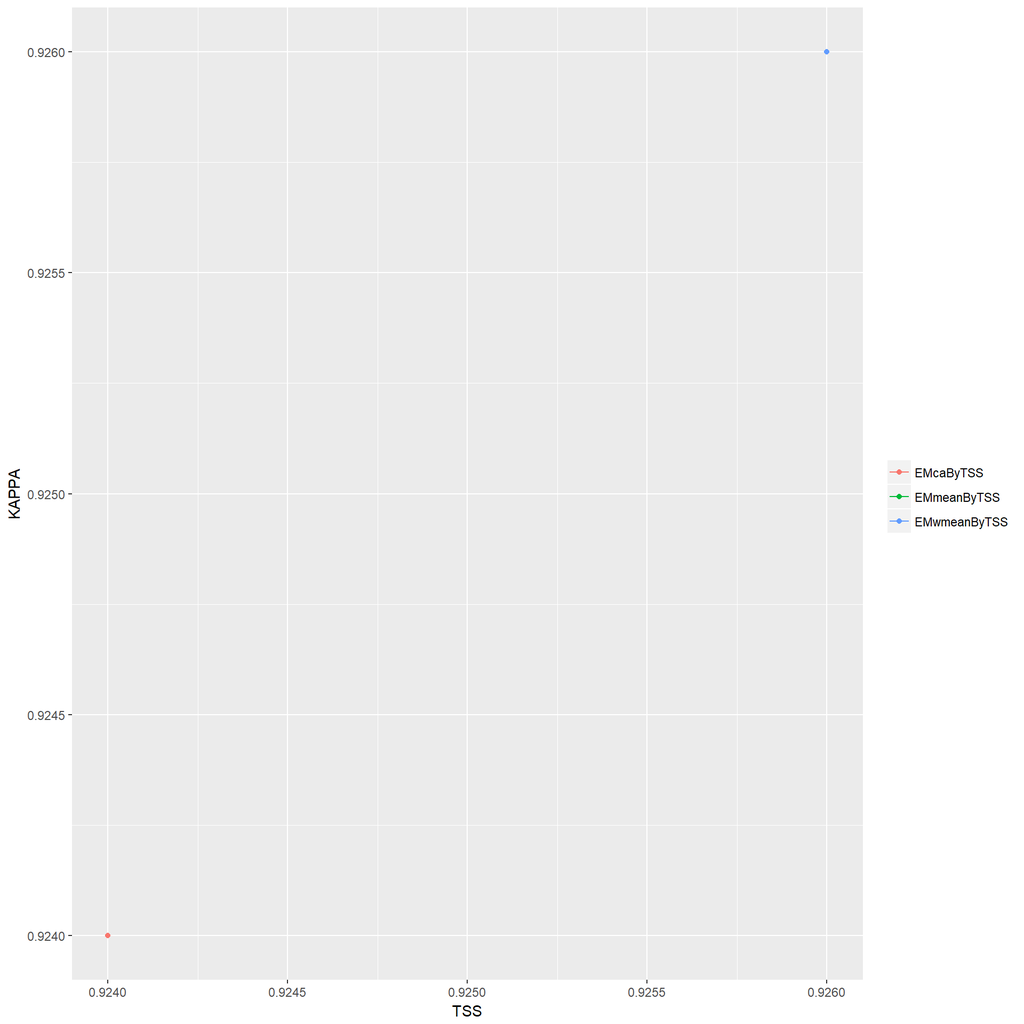

```r
## ===========================================================##
## Vizualisation
## ===========================================================##

g2 <- models_scores_graph(Yucca_brevifolia_ensemble_models, by = "models", metrics = c("TSS",
    "KAPPA"))
```

## 1.10 **Προβολή στο μέλλον**

Ας τρέξουμε την ανάλυση για το πώς θα αλλάξει η κατάσταση του είδους που μας ενδιαφέρει στο μέλλον. Αρχικά θα τρέξουμε την ανάλυση για κάθε μοντέλο ξεχωριστά (`BIOMOD_Projection`) και συνολικά (`BIOMOD_EnsembleForecasting`) για τις παρούσες συνθήκες και στη συνέχεια για τις μελλοντικές συνθήκες (με τις ίδιες εντολές, αλλά θα αλλάξουμε το `raster` αρχείο στην εντολή `new.env`):

```r
Yucca_brevifolia_models_proj_current <- BIOMOD_Projection(modeling.output = Yucca_brevifolia_models,
    new.env = var_SW_US_sub, proj.name = "current", binary.meth = "TSS", selected.models = "all",
    build.clamping.mask = TRUE, output.format = ".img", do.stack = T)
```

```r
Yucca_brevifolia_ensemble_models_proj_current <- BIOMOD_EnsembleForecasting(EM.output = Yucca_brevifolia_ensemble_models,
    projection.output = Yucca_brevifolia_models_proj_current, binary.meth = "TSS",
    output.format = ".img", do.stack = T)
```

```r
dir.create("./BIOMOD2 Modelling Outpout/Species/Yucca_brevifolia/Current/Projections/",
    recursive = TRUE, showWarnings = FALSE)

dir.create("./BIOMOD2 Modelling Outpout/Species/Yucca_brevifolia/Current/Projections/Individual",
    recursive = TRUE, showWarnings = FALSE)

dir.create("./BIOMOD2 Modelling Outpout/Species/Yucca_brevifolia/Current/Projections/Ensemble",
    recursive = TRUE, showWarnings = FALSE)

saveRDS(Yucca_brevifolia_models_proj_current, "./BIOMOD2 Modelling Outpout/Species/Yucca_brevifolia/Current/Projections/Individual/Yucca_brevifolia Current Individual Projections.rds")

saveRDS(Yucca_brevifolia_ensemble_models_proj_current, "./BIOMOD2 Modelling Outpout/Species/Yucca_brevifolia/Current/Projections/Ensemble/Yucca_brevifolia Current Ensemble Projections.rds")
```

```r
Yucca_brevifolia_proj_2070_cc26 <- BIOMOD_Projection(modeling.output = Yucca_brevifolia_models,
    new.env = var_SW_70_sub, proj.name = "2070_BC45", binary.meth = "TSS", output.format = ".img",
    do.stack = T)
```

```r
dir.create("./BIOMOD2 Modelling Outpout/Species/Yucca_brevifolia/2070", recursive = TRUE,
    showWarnings = FALSE)

dir.create("./BIOMOD2 Modelling Outpout/Species/Yucca_brevifolia/2070/Projections/",
    recursive = TRUE, showWarnings = FALSE)

dir.create("./BIOMOD2 Modelling Outpout/Species/Yucca_brevifolia/2070/Projections/Individual",
    recursive = TRUE, showWarnings = FALSE)

dir.create("./BIOMOD2 Modelling Outpout/Species/Yucca_brevifolia/2070/Projections/Ensemble",
    recursive = TRUE, showWarnings = FALSE)

saveRDS(Yucca_brevifolia_proj_2070_cc26, "./BIOMOD2 Modelling Outpout/Species/Yucca_brevifolia/2070/Projections/Individual/Yucca_brevifolia 2070 Individual Projections.rds")
```

```r
Yucca_brevifolia_ensemble_models_proj_2070_cc26 <- BIOMOD_EnsembleForecasting(EM.output = Yucca_brevifolia_ensemble_models,
    projection.output = Yucca_brevifolia_proj_2070_cc26, binary.meth = "TSS",
    output.format = ".img", do.stack = T)
```

```r
saveRDS(Yucca_brevifolia_ensemble_models_proj_2070_cc26, "./BIOMOD2 Modelling Outpout/Species/Yucca_brevifolia/2070/Projections/Ensemble/Yucca_brevifolia 2070 Ensemble Projections.rds")
```

## 1.11 **Οπτικοποιήση των συνολικών μοντέλων**

```r
stk_Yucca_brevifolia_ef_2070_cc26 <- get_predictions(Yucca_brevifolia_ensemble_models_proj_2070_cc26)

stk_Yucca_brevifolia_ef_2070_cc26 <- subset(stk_Yucca_brevifolia_ef_2070_cc26,
    grep("EMmean|EMwmean", names(stk_Yucca_brevifolia_ef_2070_cc26)))

names(stk_Yucca_brevifolia_ef_2070_cc26) <- sapply(strsplit(names(stk_Yucca_brevifolia_ef_2070_cc26),
    "_"), getElement, 2)

Yucca_brevifolia_coords <- thinned_1 %>% dplyr::select(x, y)
```

Στη συνέχεια θα οπτικοποιήσουμε το αποτέλεσμα της ανάλυσης μας έως αυτό το σημείο:

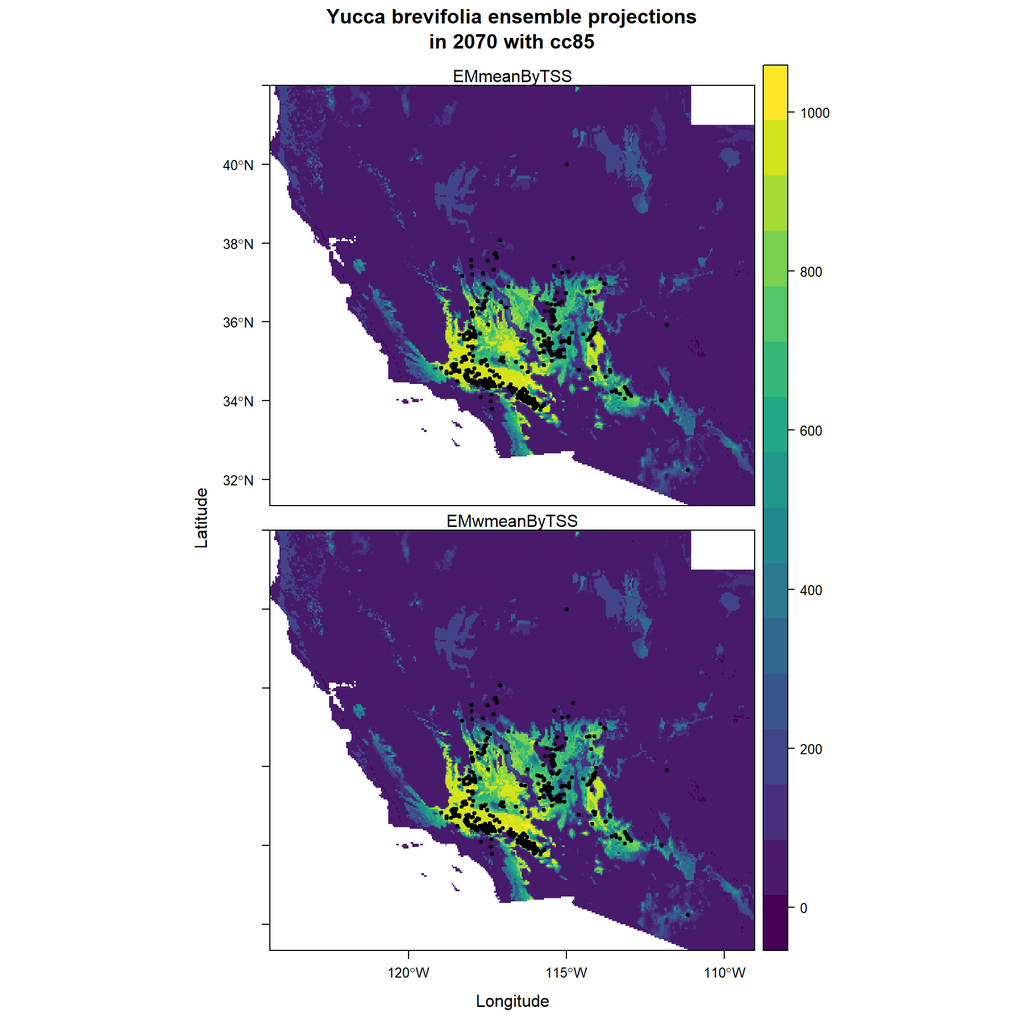

```r
library(viridis)
levelplot(stk_Yucca_brevifolia_ef_2070_cc26, main = "Yucca brevifolia ensemble projections\nin 2070 with cc85",
    col.regions = viridis(256)) + layer(sp.points(SpatialPoints(Yucca_brevifolia_coords),
    pch = 20, col = 1))
```

## 1.12 **Μεταβολή περιοχής εξάπλωσης**

```r
##==================================
## Load the the data
##==================================

## Current
YucBrev_bin_proj_current <- stack(
  c( m = "./Yucca.brevifolia/proj_current/individual_projections/Yucca.brevifolia_EMmeanByTSS_mergedAlgo_mergedRun_mergedData_TSSbin.img",
     wm = "./Yucca.brevifolia/proj_current/individual_projections/Yucca.brevifolia_EMwmeanByTSS_mergedAlgo_mergedRun_mergedData_TSSbin.img") )

## 2070
YucBrev_bin_proj_2070_BC45 <- stack(
  c( m = "./Yucca.brevifolia/proj_2070_BC45/individual_projections/Yucca.brevifolia_EMmeanByTSS_mergedAlgo_mergedRun_mergedData_TSSbin.img",
     wm = "./Yucca.brevifolia/proj_2070_BC45/individual_projections/Yucca.brevifolia_EMwmeanByTSS_mergedAlgo_mergedRun_mergedData_TSSbin.img") )


##=================================
## Species Range Change
##=================================

SRC_current_2070_BC45 <- BIOMOD_RangeSize( YucBrev_bin_proj_current,
                                           YucBrev_bin_proj_2070_BC45 )
SRC_current_2070_BC45$Compt.By.Models
```

```
##    Loss Stable0 Stable1 Gain PercLoss PercGain SpeciesRangeChange
## m  2825   62327    5296  724    34.79    8.915             -25.87
## wm 2694   62629    5174  675    34.24    8.579             -25.66
##    CurrentRangeSize FutureRangeSize.NoDisp FutureRangeSize.FullDisp
## m              8121                   5296                     6020
## wm             7868                   5174                     5849
```

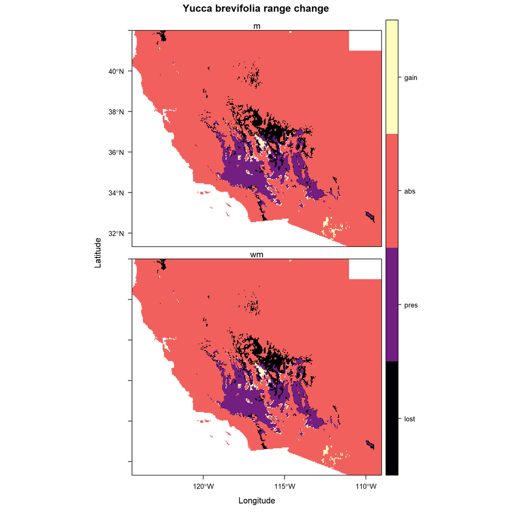

```r
YucBrev_src_map <- SRC_current_2070_BC45$Diff.By.Pixel
names(YucBrev_src_map) <- c("m cur-2070", "wm cur-2070")

##=================================
## Vizualisation
##=================================

my.at <- seq(-2.5,1.5,1)

myColorkey <- list(
                   ## color change
                   at = my.at,
                   labels = list(

                     ## labels
                     labels = c("lost", "pres", "abs","gain"),

                     ## legend
                     at = my.at[-1]-0.5
                   ))

rasterVis::levelplot( SRC_current_2070_BC45$Diff.By.Pixel,
                      main = "Yucca brevifolia range change",
                      colorkey = myColorkey,
                      layout = c(1,2) )
```

# **Βιβλιογραφία**

Araújo, M.B. & New, M. (2007) Ensemble forecasting of species distributions. *Trends Ecol. Evol.*, **22**, 42–47.

Guisan, A., Thuiller, W., & Zimmermann, N.E. (2017) *Habitat Suitability and Distribution Models with Applications in R.* Cambridge University Press,

[^1]: Προτρέξτε στους Guisan et al. (2017) για περισσότερες λεπτομέρειες - εάν χρειάζεστε περισσότερη βιβλιογραφία, απευθυνθείτε σε εμένα (εάν φυσικά το επιθυμείτε)
[^2]: Όπως θα διαπιστώσετε παρακάτω, θα εφαρμόσουμε μια τεχνική η οποία ονομάζεται ensemble modelling. Σύμφωνα με αυτή, είναι προτιμότερο και επιστημονικά ορθότερο να μην χρησιμοποιεί κανείς ένα μόνο μοντέλο (π.χ., GLM ή τo MaxEnt)
[^3]: Προσέξτε ότι πρόκειται για αρχείο xlsx και **όχι** csv - αυτό σημαίνει ότι άνοιξα στο excel το αρχείο csv, χρησιμοποίησα την εντολή `data to columns` και το έσωσα ως αρχείο xlsx
[^4]: Δεν έχει σημασία ποιό θα διαλέξουμε - έχουν όλα την ίδια πιθανότητα
[^5]: Θα μπορούσε κάποιος να αντιτείνει ότι μπορούμε να χρησιμοποιήσουμε το πακέτο `ecospat` όταν
    $$\frac{\sum{Ανεξάρτητες,\, μη\, συγγραμικές\, μεταβλητές}}{\sum{Θέσεις\, εμφάνισης}} \geq 0.1$$
[^6]: Στο βιβλίο των Guisan et al. (2017) αναφέρεται **λανθασμένα** ότι ο αριθμός των pseudoabsences πρέπει να είναι τουλάχιστον 10000 - ο αριθμός αυτός έχει να κάνει με το MaxEnt, το οποίο ανήκει στην ομάδα των P/O μοντέλων
[^7]: Καλό είναι να είναι τουλάχιστον 10 τα set αυτά, αλλά εσείς θα χρησιμοποιήσετε μόνο 2
[^8]: Θυμηθείτε να με ρωτήσετε τι σημαίνουν οι υπόλοιπες μεταβλητές